# Milestone 3 Assignment - Capstone Project

## Author - Mayuri Joshi

### Team

- Trupti Gandhi
- Priya Bhudhani
- Mayuri Joshi

## Problem and Key Insight

### Problem & Background

New York is one of the busiest cities in the world. According to Census data gathered between 2005 and 2009 54% of NYC people do not have their own car, Along with subways and buses, taxies are most popular transport. There is huge amount of data available to study the taxi trips and its travel duration and tip amount given. Studying the NYC taxi trips and fares can help predict people’s trip durations. Taxi driver companies are facing lot of issues in estimating the time required for each trip based on different circumstances like weather, time of travel and pick up and drop off locations etc.

Hence it is very essential to study and do analysis considering various factors. There are many instances where no tips are given to driver or the cases where excessive tips are given. This analysis will recommend if we need to provide tip or not, what range of tips should we provide. That’s why we found study and data analysis of the New York City Taxi driver is an important and interesting problem.

Future : This analysis will also help to create a generic model to apply on different cities of the united states.

[figure not shown]

#### Goal of this project is to build a machine learning algorithm to predict the trip duration for a taxi in New york in given weather condition

#### Task Completed as Milestone1

1. Exploratory data analysis on Trip duration dataset - Mayuri
2. Exploratory data analysis on fare tip dataset - Trupti
3. Exploratory data analysis on New york weather description dataset and New York Temperature dataset- Priya

#### Task Completed as Milestone2

1. We have merged 3 datasets namely Tripdata,FareData and Weatherdata(weather and temprature)
2. We have done exploratory data analysis (EDA) on combined merged dataset
3. Performed feature engineering and applied initial 2 machine learning algorithms
4. Predication of trip duration is my task
5. I have taken some of the important features and applied 2 Machine learning algorithms
   1. Linear regression - Accuracy 67%
   2. Random forest regression - Accuracy 71%

### Next Steps

#### In this Milestone3

I will show data mergring of 3 datasets, important key features and their visitualizations.

1. I will use XGBoost ML algorithms to predict trip_duration, select best hyperparameter for best score
2. I will use RandomsearchCV to find out best hyper parameters for Randomforest and XGBoost ML aglorithms.
3. I will find out the Best Accuracy based on R2square and MSE
4. I will do the comparison based on R2Square
5. Conclude and select approriate algorithm

## Data Exploration and Preparation

```python
#### Data Sources
```

```python
# Datasets location
NewYorkTripDataURL = "https://library.startlearninglabs.uw.edu/DATASCI420/Datasets/New%20York%20Taxi%202013/NYC_Taxi_2013_One_Percent_Trip.csv"
NewYorkFareDataURL = "https://library.startlearninglabs.uw.edu/DATASCI420/Datasets/New%20York%20Taxi%202013/NYC_Taxi_2013_One_Percent_Fare.csv"
WeatherData = 'Taxi_Weather.csv'
```

```python
# Import libraries
import pandas as pd
import numpy as np
import seaborn as sns
import matplotlib.pyplot as plt
%matplotlib inline

from matplotlib.backends.backend_pdf import PdfPages

import os
import sys
import time
import requests
import datetime
import math
```

```python
# Quick Overview of data
```

```python
WeatherData = pd.read_csv("Taxi_Weather.csv")
WeatherData.head()
```

|  | Unnamed: 0 | datetime | temperature | year | hour | monthnumber | monthname | weatherdescription | weather_type | daytime | Season | hour_total |
| --- | --- | --- | --- | --- | --- | --- | --- | --- | --- | --- | --- | --- |
| 0 | 0 | 2013-01-01 00:00:00 | 272.03 | 2013 | 0 | 1 | Jan | few clouds | Cloudy | Night | Winter | 1 |
| 1 | 1 | 2013-01-01 01:00:00 | 271.46 | 2013 | 1 | 1 | Jan | few clouds | Cloudy | Night | Winter | 1 |
| 2 | 2 | 2013-01-01 02:00:00 | 271.19 | 2013 | 2 | 1 | Jan | few clouds | Cloudy | Night | Winter | 1 |
| 3 | 3 | 2013-01-01 03:00:00 | 271.07 | 2013 | 3 | 1 | Jan | few clouds | Cloudy | Night | Winter | 1 |
| 4 | 4 | 2013-01-01 04:00:00 | 270.83 | 2013 | 4 | 1 | Jan | sky is clear | Clear Cloud | Night | Winter | 1 |

```python
# changing the datetime column into datetime64[ns]
WeatherData['datetime']= pd.to_datetime(WeatherData['datetime'])
WeatherData["hour"] =WeatherData.datetime.dt.hour
WeatherData["pickup_month"] = WeatherData.datetime.dt.month
WeatherData["date"] =WeatherData.datetime.dt.date
```

```python
Tripdata = pd.read_csv(NewYorkTripDataURL,header=0)
Tripdata.head()
```

|  | medallion | hack_license | vendor_id | rate_code | store_and_fwd_flag | pickup_datetime | dropoff_datetime | passenger_count | trip_time_in_secs | trip_distance | pickup_longitude | pickup_latitude | dropoff_longitude | dropoff_latitude |
| --- | --- | --- | --- | --- | --- | --- | --- | --- | --- | --- | --- | --- | --- | --- |
| 0 | 00005007A9F30E289E760362F69E4EAD | A9AE329EA1138052DAC8FDFD8BA86603 | CMT | 1 | N | 3/8/2013 9:55:27 PM | 3/8/2013 10:05:59 PM | 2 | 631 | 2.5 | -73.959610 | 40.715942 | -73.963417 | 40.692169 |
| 1 | 00005007A9F30E289E760362F69E4EAD | A9AE329EA1138052DAC8FDFD8BA86603 | CMT | 1 | N | 3/9/2013 6:51:52 PM | 3/9/2013 7:02:59 PM | 2 | 666 | 1.8 | -73.973373 | 40.763958 | -73.977303 | 40.782139 |
| 2 | 00005007A9F30E289E760362F69E4EAD | A9AE329EA1138052DAC8FDFD8BA86603 | CMT | 1 | N | 3/9/2013 7:04:35 PM | 3/9/2013 7:27:57 PM | 2 | 1401 | 4.4 | -73.977837 | 40.782818 | -74.000893 | 40.737076 |
| 3 | 00005007A9F30E289E760362F69E4EAD | A9AE329EA1138052DAC8FDFD8BA86603 | CMT | 1 | N | 3/9/2013 8:33:06 PM | 3/9/2013 8:45:38 PM | 1 | 751 | 2.8 | -73.980331 | 40.784382 | -73.984291 | 40.748688 |
| 4 | 00005007A9F30E289E760362F69E4EAD | A9AE329EA1138052DAC8FDFD8BA86603 | CMT | 1 | N | 3/9/2013 11:10:38 PM | 3/9/2013 11:14:59 PM | 1 | 261 | 1.5 | -73.986687 | 40.749474 | -73.990677 | 40.762524 |

```python
Tripdata.shape
```

```
(1703987, 14)
```

```python
Tripdata.isnull().sum()
```

```
medallion                  0
hack_license               0
vendor_id                  0
rate_code                  0
store_and_fwd_flag    856666
pickup_datetime            0
dropoff_datetime           0
passenger_count            0
trip_time_in_secs          0
trip_distance              0
pickup_longitude           0
pickup_latitude            0
dropoff_longitude          0
dropoff_latitude           0
dtype: int64
```

```python
Tripdata['store_and_fwd_flag'] = Tripdata['store_and_fwd_flag'].replace(['N  '], 'N')
Tripdata['store_and_fwd_flag'] = Tripdata['store_and_fwd_flag'].replace(['Y  '], 'Y')
Tripdata.fillna('N', inplace=True)
```

```python
Tripdata.isnull().sum()
```

```
medallion             0
hack_license          0
vendor_id             0
rate_code             0
store_and_fwd_flag    0
pickup_datetime       0
dropoff_datetime      0
passenger_count       0
trip_time_in_secs     0
trip_distance         0
pickup_longitude      0
pickup_latitude       0
dropoff_longitude     0
dropoff_latitude      0
dtype: int64
```

```python
def trans_store_and_fwd_flag(x):
    if x == 'N':
        return 0
    if x == 'Y':
        return 1
```

```python
Tripdata["store_and_fwd_flag"] = Tripdata["store_and_fwd_flag"].apply(trans_store_and_fwd_flag)
```

```python
# Read Fare data
FareData = pd.read_csv(NewYorkFareDataURL,header=0)
FareData.head()
```

|  | medallion | hack_license | vendor_id | pickup_datetime | payment_type | fare_amount | surcharge | mta_tax | tolls_amount | total_amount | tip_amount |
| --- | --- | --- | --- | --- | --- | --- | --- | --- | --- | --- | --- |
| 0 | 00005007A9F30E289E760362F69E4EAD | A9AE329EA1138052DAC8FDFD8BA86603 | CMT | 3/8/2013 9:55:27 PM | CSH | 10.5 | 0.5 | 0.5 | 0.0 | 11.5 | 0.0 |
| 1 | 00005007A9F30E289E760362F69E4EAD | A9AE329EA1138052DAC8FDFD8BA86603 | CMT | 3/9/2013 6:51:52 PM | CRD | 9.5 | 0.0 | 0.5 | 0.0 | 12.0 | 2.0 |
| 2 | 00005007A9F30E289E760362F69E4EAD | A9AE329EA1138052DAC8FDFD8BA86603 | CMT | 3/9/2013 7:04:35 PM | CSH | 18.0 | 0.0 | 0.5 | 0.0 | 18.5 | 0.0 |
| 3 | 00005007A9F30E289E760362F69E4EAD | A9AE329EA1138052DAC8FDFD8BA86603 | CMT | 3/9/2013 8:33:06 PM | CSH | 11.5 | 0.5 | 0.5 | 0.0 | 12.5 | 0.0 |
| 4 | 00005007A9F30E289E760362F69E4EAD | A9AE329EA1138052DAC8FDFD8BA86603 | CMT | 3/9/2013 11:10:38 PM | CRD | 6.0 | 0.5 | 0.5 | 0.0 | 8.4 | 1.4 |

```python
FareData.shape
```

```
(1703987, 11)
```

```python
FareData.isnull().sum()
```

```
medallion          0
hack_license       0
vendor_id          0
pickup_datetime    0
payment_type       0
fare_amount        0
surcharge          0
mta_tax            0
tolls_amount       0
total_amount       0
tip_amount         0
dtype: int64
```

```python
# Merging of Trip and Tip datasets
TripandFareMerge = pd.merge(Tripdata,FareData)
TripandFareMerge.head()
```

|  | medallion | hack_license | vendor_id | rate_code | store_and_fwd_flag | pickup_datetime | dropoff_datetime | passenger_count | trip_time_in_secs | trip_distance | ... | pickup_latitude | dropoff_longitude | dropoff_latitude | payment_type | fare_amount | surcharge | mta_tax | tolls_amount | total_amount | tip_amount |
| --- | --- | --- | --- | --- | --- | --- | --- | --- | --- | --- | --- | --- | --- | --- | --- | --- | --- | --- | --- | --- | --- |
| 0 | 00005007A9F30E289E760362F69E4EAD | A9AE329EA1138052DAC8FDFD8BA86603 | CMT | 1 | 0 | 3/8/2013 9:55:27 PM | 3/8/2013 10:05:59 PM | 2 | 631 | 2.5 | ... | 40.715942 | -73.963417 | 40.692169 | CSH | 10.5 | 0.5 | 0.5 | 0.0 | 11.5 | 0.0 |
| 1 | 00005007A9F30E289E760362F69E4EAD | A9AE329EA1138052DAC8FDFD8BA86603 | CMT | 1 | 0 | 3/9/2013 6:51:52 PM | 3/9/2013 7:02:59 PM | 2 | 666 | 1.8 | ... | 40.763958 | -73.977303 | 40.782139 | CRD | 9.5 | 0.0 | 0.5 | 0.0 | 12.0 | 2.0 |
| 2 | 00005007A9F30E289E760362F69E4EAD | A9AE329EA1138052DAC8FDFD8BA86603 | CMT | 1 | 0 | 3/9/2013 7:04:35 PM | 3/9/2013 7:27:57 PM | 2 | 1401 | 4.4 | ... | 40.782818 | -74.000893 | 40.737076 | CSH | 18.0 | 0.0 | 0.5 | 0.0 | 18.5 | 0.0 |
| 3 | 00005007A9F30E289E760362F69E4EAD | A9AE329EA1138052DAC8FDFD8BA86603 | CMT | 1 | 0 | 3/9/2013 8:33:06 PM | 3/9/2013 8:45:38 PM | 1 | 751 | 2.8 | ... | 40.784382 | -73.984291 | 40.748688 | CSH | 11.5 | 0.5 | 0.5 | 0.0 | 12.5 | 0.0 |
| 4 | 00005007A9F30E289E760362F69E4EAD | A9AE329EA1138052DAC8FDFD8BA86603 | CMT | 1 | 0 | 3/9/2013 11:10:38 PM | 3/9/2013 11:14:59 PM | 1 | 261 | 1.5 | ... | 40.749474 | -73.990677 | 40.762524 | CRD | 6.0 | 0.5 | 0.5 | 0.0 | 8.4 | 1.4 |

5 rows × 21 columns

```python
TripandFareMerge["pickup_datetime"] = pd.to_datetime(TripandFareMerge["pickup_datetime"])
TripandFareMerge["dropoff_datetime"] = pd.to_datetime(TripandFareMerge["dropoff_datetime"])
```

```python
TripandFareMerge["pickup_datetime"] = pd.to_datetime(TripandFareMerge["pickup_datetime"])
TripandFareMerge["dropoff_datetime"] = pd.to_datetime(TripandFareMerge["dropoff_datetime"])


#Extracting DOW information 0-6 Mon-Sun
TripandFareMerge['Year'] = TripandFareMerge['pickup_datetime'].dt.year
TripandFareMerge['DOW'] = TripandFareMerge['pickup_datetime'].dt.dayofweek
TripandFareMerge["pickup_weekday_name"] = TripandFareMerge.pickup_datetime.dt.weekday_name
#TripandFareMerge["pickup_hour"] = TripandFareMerge.pickup_datetime.dt.hour
TripandFareMerge['hour'] = TripandFareMerge.pickup_datetime.dt.hour
TripandFareMerge['date'] = TripandFareMerge['pickup_datetime'].dt.date
display(TripandFareMerge['pickup_datetime'].describe())



display(TripandFareMerge.info())
```

```
count                 1704065
unique                1196352
top       2013-04-27 09:11:00
freq                       21
first     2013-01-01 00:00:16
last      2013-12-31 23:59:22
Name: pickup_datetime, dtype: object
```

```
<class 'pandas.core.frame.DataFrame'>
Int64Index: 1704065 entries, 0 to 1704064
Data columns (total 26 columns):
medallion              object
hack_license           object
vendor_id              object
rate_code              int64
store_and_fwd_flag     int64
pickup_datetime        datetime64[ns]
dropoff_datetime       datetime64[ns]
passenger_count        int64
trip_time_in_secs      int64
trip_distance          float64
pickup_longitude       float64
pickup_latitude        float64
dropoff_longitude      float64
dropoff_latitude       float64
payment_type           object
fare_amount            float64
surcharge              float64
mta_tax                float64
tolls_amount           float64
total_amount           float64
tip_amount             float64
Year                   int64
DOW                    int64
pickup_weekday_name    object
hour                   int64
date                   object
dtypes: datetime64[ns](2), float64(11), int64(7), object(6)
memory usage: 351.0+ MB
```

```
None
```

```python
# checking the tip with date
df_date = TripandFareMerge.pickup_datetime
df_tip_amount = TripandFareMerge.tip_amount
date_tip= TripandFareMerge.loc[:, ['pickup_datetime','tip_amount']]

datetime_plot = pd.DataFrame(date_tip).set_index('pickup_datetime', drop=True)
datetime_plot.head()
```

| pickup_datetime | tip_amount |
| --- | --- |
| 2013-03-08 21:55:27 | 0.0 |
| 2013-03-09 18:51:52 | 2.0 |
| 2013-03-09 19:04:35 | 0.0 |
| 2013-03-09 20:33:06 | 0.0 |
| 2013-03-09 23:10:38 | 1.4 |

```python
#Removing Negative values for mta_tax
df_mta_amount = TripandFareMerge[TripandFareMerge['mta_tax'] <0 ]
TripandFareMerge=TripandFareMerge.drop(df_mta_amount.index, axis = 0)
#Removing Negative values for surcharges
df_surcharge_amount = TripandFareMerge[TripandFareMerge['surcharge'] <0 ]
TripandFareMerge =TripandFareMerge.drop(df_surcharge_amount.index, axis = 0)
#Removing Negative values for total amount
df_total_amount =TripandFareMerge[TripandFareMerge['total_amount'] <0 ]
TripandFareMerge =TripandFareMerge.drop(df_total_amount.index, axis = 0)
# #Removing Negative values for fare amount
df_fare_amount = TripandFareMerge[TripandFareMerge['fare_amount'] <0 ]
TripandFareMerge =TripandFareMerge.drop(df_fare_amount.index, axis = 0)
```

```python
# Concatenate weather data
```

```python
TripandFareMerge.head()
```

|  | medallion | hack_license | vendor_id | rate_code | store_and_fwd_flag | pickup_datetime | dropoff_datetime | passenger_count | trip_time_in_secs | trip_distance | ... | surcharge | mta_tax | tolls_amount | total_amount | tip_amount | Year | DOW | pickup_weekday_name | hour | date |
| --- | --- | --- | --- | --- | --- | --- | --- | --- | --- | --- | --- | --- | --- | --- | --- | --- | --- | --- | --- | --- | --- |
| 0 | 00005007A9F30E289E760362F69E4EAD | A9AE329EA1138052DAC8FDFD8BA86603 | CMT | 1 | 0 | 2013-03-08 21:55:27 | 2013-03-08 22:05:59 | 2 | 631 | 2.5 | ... | 0.5 | 0.5 | 0.0 | 11.5 | 0.0 | 2013 | 4 | Friday | 21 | 2013-03-08 |
| 1 | 00005007A9F30E289E760362F69E4EAD | A9AE329EA1138052DAC8FDFD8BA86603 | CMT | 1 | 0 | 2013-03-09 18:51:52 | 2013-03-09 19:02:59 | 2 | 666 | 1.8 | ... | 0.0 | 0.5 | 0.0 | 12.0 | 2.0 | 2013 | 5 | Saturday | 18 | 2013-03-09 |
| 2 | 00005007A9F30E289E760362F69E4EAD | A9AE329EA1138052DAC8FDFD8BA86603 | CMT | 1 | 0 | 2013-03-09 19:04:35 | 2013-03-09 19:27:57 | 2 | 1401 | 4.4 | ... | 0.0 | 0.5 | 0.0 | 18.5 | 0.0 | 2013 | 5 | Saturday | 19 | 2013-03-09 |
| 3 | 00005007A9F30E289E760362F69E4EAD | A9AE329EA1138052DAC8FDFD8BA86603 | CMT | 1 | 0 | 2013-03-09 20:33:06 | 2013-03-09 20:45:38 | 1 | 751 | 2.8 | ... | 0.5 | 0.5 | 0.0 | 12.5 | 0.0 | 2013 | 5 | Saturday | 20 | 2013-03-09 |
| 4 | 00005007A9F30E289E760362F69E4EAD | A9AE329EA1138052DAC8FDFD8BA86603 | CMT | 1 | 0 | 2013-03-09 23:10:38 | 2013-03-09 23:14:59 | 1 | 261 | 1.5 | ... | 0.5 | 0.5 | 0.0 | 8.4 | 1.4 | 2013 | 5 | Saturday | 23 | 2013-03-09 |

5 rows × 26 columns

```python
WeatherData.head()
```

|  | Unnamed: 0 | datetime | temperature | year | hour | monthnumber | monthname | weatherdescription | weather_type | daytime | Season | hour_total | pickup_month | date |
| --- | --- | --- | --- | --- | --- | --- | --- | --- | --- | --- | --- | --- | --- | --- |
| 0 | 0 | 2013-01-01 00:00:00 | 272.03 | 2013 | 0 | 1 | Jan | few clouds | Cloudy | Night | Winter | 1 | 1 | 2013-01-01 |
| 1 | 1 | 2013-01-01 01:00:00 | 271.46 | 2013 | 1 | 1 | Jan | few clouds | Cloudy | Night | Winter | 1 | 1 | 2013-01-01 |
| 2 | 2 | 2013-01-01 02:00:00 | 271.19 | 2013 | 2 | 1 | Jan | few clouds | Cloudy | Night | Winter | 1 | 1 | 2013-01-01 |
| 3 | 3 | 2013-01-01 03:00:00 | 271.07 | 2013 | 3 | 1 | Jan | few clouds | Cloudy | Night | Winter | 1 | 1 | 2013-01-01 |
| 4 | 4 | 2013-01-01 04:00:00 | 270.83 | 2013 | 4 | 1 | Jan | sky is clear | Clear Cloud | Night | Winter | 1 | 1 | 2013-01-01 |

```python
TripFareWeatherData = pd.merge(TripandFareMerge, WeatherData,  how='left', sort=True,
on=['date','hour'])
TripFareWeatherData.head(10)
```

|  | medallion | hack_license | vendor_id | rate_code | store_and_fwd_flag | pickup_datetime | dropoff_datetime | passenger_count | trip_time_in_secs | trip_distance | ... | temperature | year | monthnumber | monthname | weatherdescription | weather_type | daytime | Season | hour_total | pickup_month |
| --- | --- | --- | --- | --- | --- | --- | --- | --- | --- | --- | --- | --- | --- | --- | --- | --- | --- | --- | --- | --- | --- |
| 0 | 00E67F2CAC914F384C9803F02C7F85D9 | D33D2B6EB5B863CF167D251FEADFF165 | VTS | 1 | 0 | 2013-01-01 00:20:00 | 2013-01-01 00:30:00 | 4 | 600 | 2.47 | ... | 272.03 | 2013 | 1 | Jan | few clouds | Cloudy | Night | Winter | 1 | 1 |
| 1 | 00E67F2CAC914F384C9803F02C7F85D9 | D33D2B6EB5B863CF167D251FEADFF165 | VTS | 1 | 0 | 2013-01-01 00:34:00 | 2013-01-01 00:48:00 | 5 | 840 | 4.71 | ... | 272.03 | 2013 | 1 | Jan | few clouds | Cloudy | Night | Winter | 1 | 1 |
| 2 | 00E67F2CAC914F384C9803F02C7F85D9 | D33D2B6EB5B863CF167D251FEADFF165 | VTS | 1 | 0 | 2013-01-01 00:51:00 | 2013-01-01 01:03:00 | 4 | 720 | 2.18 | ... | 272.03 | 2013 | 1 | Jan | few clouds | Cloudy | Night | Winter | 1 | 1 |
| 3 | 059E5BF1D421092E005D3A74304CEED3 | D8AA5AEE5F1CBB3897197CAA992902F4 | VTS | 1 | 0 | 2013-01-01 00:34:00 | 2013-01-01 00:40:00 | 1 | 360 | 0.25 | ... | 272.03 | 2013 | 1 | Jan | few clouds | Cloudy | Night | Winter | 1 | 1 |
| 4 | 059E5BF1D421092E005D3A74304CEED3 | D8AA5AEE5F1CBB3897197CAA992902F4 | VTS | 1 | 0 | 2013-01-01 00:19:00 | 2013-01-01 00:34:00 | 1 | 900 | 1.36 | ... | 272.03 | 2013 | 1 | Jan | few clouds | Cloudy | Night | Winter | 1 | 1 |
| 5 | 059E5BF1D421092E005D3A74304CEED3 | D8AA5AEE5F1CBB3897197CAA992902F4 | VTS | 1 | 0 | 2013-01-01 00:48:00 | 2013-01-01 01:00:00 | 1 | 720 | 3.21 | ... | 272.03 | 2013 | 1 | Jan | few clouds | Cloudy | Night | Winter | 1 | 1 |
| 6 | 087FC8B3829AE79170ADFCDF8F501BD4 | F43E8FCE60957A64DF4ABD4D0114ADCA | VTS | 1 | 0 | 2013-01-01 00:10:00 | 2013-01-01 00:27:00 | 1 | 1020 | 2.49 | ... | 272.03 | 2013 | 1 | Jan | few clouds | Cloudy | Night | Winter | 1 | 1 |
| 7 | 087FC8B3829AE79170ADFCDF8F501BD4 | F43E8FCE60957A64DF4ABD4D0114ADCA | VTS | 1 | 0 | 2013-01-01 00:01:00 | 2013-01-01 00:08:00 | 1 | 420 | 1.79 | ... | 272.03 | 2013 | 1 | Jan | few clouds | Cloudy | Night | Winter | 1 | 1 |
| 8 | 087FC8B3829AE79170ADFCDF8F501BD4 | F43E8FCE60957A64DF4ABD4D0114ADCA | VTS | 1 | 0 | 2013-01-01 00:49:00 | 2013-01-01 01:00:00 | 1 | 660 | 1.49 | ... | 272.03 | 2013 | 1 | Jan | few clouds | Cloudy | Night | Winter | 1 | 1 |
| 9 | 087FC8B3829AE79170ADFCDF8F501BD4 | F43E8FCE60957A64DF4ABD4D0114ADCA | VTS | 1 | 0 | 2013-01-01 00:38:00 | 2013-01-01 00:48:00 | 1 | 600 | 1.47 | ... | 272.03 | 2013 | 1 | Jan | few clouds | Cloudy | Night | Winter | 1 | 1 |

10 rows × 38 columns

## EDA on Merged datasets

### We have merged 4 data sets here Weather, temparture, Fare and Trip

```python
# #Removing the outliers in the dataset
TripFareWeatherData = TripFareWeatherData[TripFareWeatherData["trip_time_in_secs"] < 400000]
```

```python
# #Removing the outliers in the dataset
TripFareWeatherData = TripFareWeatherData[TripFareWeatherData["trip_distance"] < 8000]
```

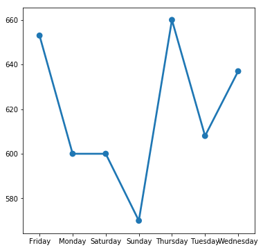

```python
Tripdata_agg = TripFareWeatherData.groupby('pickup_weekday_name')['trip_time_in_secs'].aggregate(np.median).reset_index()
fig = plt.figure(4)
plt.figure(figsize=(6,6))
sns.pointplot(Tripdata_agg.pickup_weekday_name.values, Tripdata_agg.trip_time_in_secs.values)
plt.show()
```

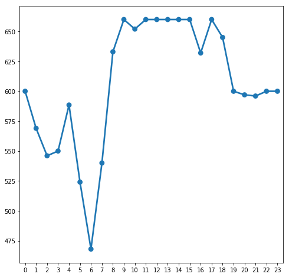

```python
Tripdata_agg = TripFareWeatherData.groupby('hour')['trip_time_in_secs'].aggregate(np.median).reset_index()
fig = plt.figure(5)
plt.figure(figsize=(8,8))
sns.pointplot(Tripdata_agg.hour.values, Tripdata_agg.trip_time_in_secs.values)
plt.show()
```

```python
from math import radians, sin, cos, sqrt, asin
def haversine(columns):
  lat1, lon1, lat2, lon2 = columns
  R = 6372.8 # Earth radius in kilometers

  dLat = radians(lat2 - lat1)
  dLon = radians(lon2 - lon1)
  lat1 = radians(lat1)
  lat2 = radians(lat2)

  a = sin(dLat/2)**2 + cos(lat1)*cos(lat2)*sin(dLon/2)**2
  c = 2*asin(sqrt(a))

  return R * c
cols = ['pickup_latitude','pickup_longitude','dropoff_latitude','dropoff_longitude']
distances = TripFareWeatherData[cols].apply(
    lambda x: haversine(x),axis = 1
)
TripFareWeatherData['haversine_distances'] = distances.copy()
TripFareWeatherData.head()
```

|  | medallion | hack_license | vendor_id | rate_code | store_and_fwd_flag | pickup_datetime | dropoff_datetime | passenger_count | trip_time_in_secs | trip_distance | ... | year | monthnumber | monthname | weatherdescription | weather_type | daytime | Season | hour_total | pickup_month | haversine_distances |
| --- | --- | --- | --- | --- | --- | --- | --- | --- | --- | --- | --- | --- | --- | --- | --- | --- | --- | --- | --- | --- | --- |
| 0 | 00E67F2CAC914F384C9803F02C7F85D9 | D33D2B6EB5B863CF167D251FEADFF165 | VTS | 1 | 0 | 2013-01-01 00:20:00 | 2013-01-01 00:30:00 | 4 | 600 | 2.47 | ... | 2013 | 1 | Jan | few clouds | Cloudy | Night | Winter | 1 | 1 | 3.054433 |
| 1 | 00E67F2CAC914F384C9803F02C7F85D9 | D33D2B6EB5B863CF167D251FEADFF165 | VTS | 1 | 0 | 2013-01-01 00:34:00 | 2013-01-01 00:48:00 | 5 | 840 | 4.71 | ... | 2013 | 1 | Jan | few clouds | Cloudy | Night | Winter | 1 | 1 | 4.756856 |
| 2 | 00E67F2CAC914F384C9803F02C7F85D9 | D33D2B6EB5B863CF167D251FEADFF165 | VTS | 1 | 0 | 2013-01-01 00:51:00 | 2013-01-01 01:03:00 | 4 | 720 | 2.18 | ... | 2013 | 1 | Jan | few clouds | Cloudy | Night | Winter | 1 | 1 | 2.492664 |
| 3 | 059E5BF1D421092E005D3A74304CEED3 | D8AA5AEE5F1CBB3897197CAA992902F4 | VTS | 1 | 0 | 2013-01-01 00:34:00 | 2013-01-01 00:40:00 | 1 | 360 | 0.25 | ... | 2013 | 1 | Jan | few clouds | Cloudy | Night | Winter | 1 | 1 | 1.906787 |
| 4 | 059E5BF1D421092E005D3A74304CEED3 | D8AA5AEE5F1CBB3897197CAA992902F4 | VTS | 1 | 0 | 2013-01-01 00:19:00 | 2013-01-01 00:34:00 | 1 | 900 | 1.36 | ... | 2013 | 1 | Jan | few clouds | Cloudy | Night | Winter | 1 | 1 | 1.420027 |

5 rows × 39 columns

```python
lowq,highq = 1,99

#Trimming based on outlier distances and durations
trip = TripFareWeatherData['trip_time_in_secs']
ltrip,rtrip= np.percentile(trip,[lowq,highq])
print(ltrip,rtrip)
train_trimmed = TripFareWeatherData[trip.between(ltrip,rtrip)]

haversine=TripFareWeatherData['haversine_distances']
ltrip,rtrip= np.percentile(haversine,[lowq,highq])
print(ltrip,rtrip)
train_trimmed = train_trimmed[haversine.between(ltrip,rtrip)]
train_trimmed.shape
```

```
80.0 2820.0
0.00670579863818 20.519380257
```

```
(1646408, 39)
```

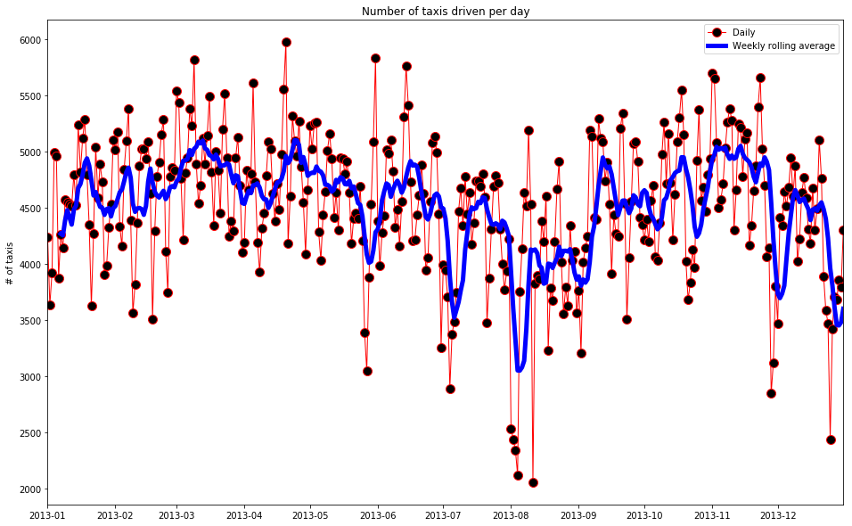

```python
dates=train_trimmed['pickup_datetime'].dt.date
date_sorted=dates.value_counts().sort_index()

date_sorted.plot(marker='.',ms=20,c='r',mfc='k',figsize=(16,10),
                 rot=45,lw=1,#linestyle='None'
                 title='Number of taxis driven per day',
                label='Daily')
date_rolling=date_sorted.rolling(window=7).mean()
date_rolling.plot(c='b',label='Weekly rolling average',lw=5)
plt.legend()
plt.ylabel('# of taxis')
plt.show()
fig = plt.figure(6)
```

```python
### We can observe that there is drastic drop in the Taxi trips in Month of August
```

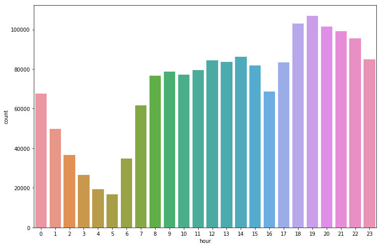

```python
plt.figure(figsize=(12,8))
sns.countplot(x="hour", data=TripFareWeatherData)
plt.show()
```

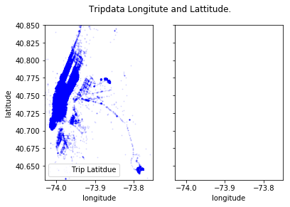

```python
N = 100000

city_long_border = (-74.03, -73.75)
city_lat_border = (40.63, 40.85)
fig, ax = plt.subplots(ncols=2, sharex=True, sharey=True)
ax[0].scatter(TripFareWeatherData['pickup_longitude'].values[:N], TripFareWeatherData['pickup_latitude'].values[:N],
              color='blue', s=1, label='Trip Latitdue', alpha=0.1)

fig.suptitle('Tripdata Longitute and Lattitude.')
ax[0].legend(loc=0)
ax[0].set_ylabel('latitude')
ax[0].set_xlabel('longitude')
ax[1].set_xlabel('longitude')
ax[1].legend(loc=0)
plt.ylim(city_lat_border)
plt.xlim(city_long_border)
plt.show()
```

```python
TripFareWeatherData.info()
```

```
<class 'pandas.core.frame.DataFrame'>
Int64Index: 1704013 entries, 0 to 1704044
Data columns (total 39 columns):
medallion              object
hack_license           object
vendor_id              object
rate_code              int64
store_and_fwd_flag     int64
pickup_datetime        datetime64[ns]
dropoff_datetime       datetime64[ns]
passenger_count        int64
trip_time_in_secs      int64
trip_distance          float64
pickup_longitude       float64
pickup_latitude        float64
dropoff_longitude      float64
dropoff_latitude       float64
payment_type           object
fare_amount            float64
surcharge              float64
mta_tax                float64
tolls_amount           float64
total_amount           float64
tip_amount             float64
Year                   int64
DOW                    int64
pickup_weekday_name    object
hour                   int64
date                   object
Unnamed: 0             int64
datetime               datetime64[ns]
temperature            float64
year                   int64
monthnumber            int64
monthname              object
weatherdescription     object
weather_type           object
daytime                object
Season                 object
hour_total             int64
pickup_month           int64
haversine_distances    float64
dtypes: datetime64[ns](3), float64(13), int64(12), object(11)
memory usage: 600.0+ MB
```

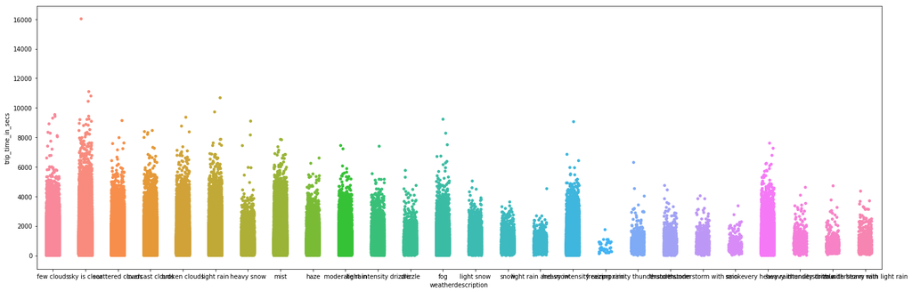

```python
f, ax = plt.subplots(figsize=(25, 8))
sns.stripplot(data = TripFareWeatherData, x='weatherdescription', y='trip_time_in_secs', jitter=.2)
plt.show()
```

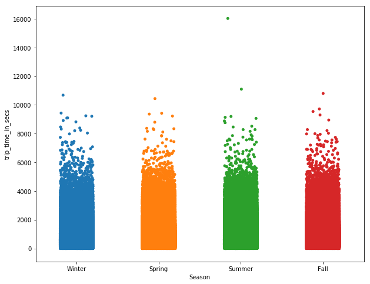

```python
f, ax = plt.subplots(figsize=(10, 8))
sns.stripplot(data = TripFareWeatherData, x='Season', y='trip_time_in_secs', jitter=.2)
plt.show()
```

## Feature Engineering and Selection

[output not shown]

[output cut: 17 more lines]

[output not shown]

Overview

Dataset info

| Number of variables | 40 |
| --- | --- |
| Number of observations | 1704013 |
| Total Missing (%) | 0.0% |
| Total size in memory | 520.0 MiB |
| Average record size in memory | 320.0 B |

Variables types

| Numeric | 14 |
| --- | --- |
| Categorical | 11 |
| Boolean | 2 |
| Date | 3 |
| Text (Unique) | 0 |
| Rejected | 10 |
| Unsupported | 0 |

Warnings

- `DOW` has 221555 / 13.0% zeros Zeros

- `Unnamed: 0` is highly correlated with `index` (ρ = 0.99975) Rejected

- `Year` has constant value 2013 Rejected

- `date` has a high cardinality: 365 distinct values Warning

- `dropoff_latitude` is highly correlated with `pickup_latitude` (ρ = 0.93111) Rejected

- `dropoff_longitude` is highly correlated with `pickup_longitude` (ρ = 0.99538) Rejected

- `fare_amount` is highly correlated with `trip_distance` (ρ = 0.90769) Rejected

- `hack_license` has a high cardinality: 23709 distinct values Warning

- `haversine_distances` is highly skewed (γ1 = 189.15) Skewed

- `hour` has 67732 / 4.0% zeros Zeros

- `hour_total` has constant value 1 Rejected

- `medallion` has a high cardinality: 11845 distinct values Warning

- `monthnumber` is highly correlated with `Unnamed: 0` (ρ = 0.99661) Rejected

- `pickup_latitude` is highly skewed (γ1 = -77.488) Skewed

- `pickup_month` is highly correlated with `monthnumber` (ρ = 1) Rejected

- `rate_code` is highly skewed (γ1 = 291.13) Skewed

- `surcharge` has 864222 / 50.7% zeros Zeros

- `tip_amount` has 811324 / 47.6% zeros Zeros

- `tolls_amount` has 1626838 / 95.5% zeros Zeros

- `total_amount` is highly correlated with `fare_amount` (ρ = 0.98294) Rejected

- `year` has constant value 2013 Rejected

Variables

DOW  
Numeric

| Distinct count | 7 |
| --- | --- |
| Unique (%) | 0.0% |
| Missing (%) | 0.0% |
| Missing (n) | 0 |
| Infinite (%) | 0.0% |
| Infinite (n) | 0 |

| Mean | 3.0357 |
| --- | --- |
| Minimum | 0 |
| Maximum | 6 |
| Zeros (%) | 13.0% |

Toggle details

**Statistics**

Quantile statistics

| Minimum | 0 |
| --- | --- |
| 5-th percentile | 0 |
| Q1 | 1 |
| Median | 3 |
| Q3 | 5 |
| 95-th percentile | 6 |
| Maximum | 6 |
| Range | 6 |
| Interquartile range | 4 |

Descriptive statistics

| Standard deviation | 1.9561 |
| --- | --- |
| Coef of variation | 0.64437 |
| Kurtosis | -1.2084 |
| Mean | 3.0357 |
| MAD | 1.674 |
| Skewness | -0.035023 |
| Sum | 5172791 |
| Variance | 3.8263 |
| Memory size | 13.0 MiB |

**Histogram**

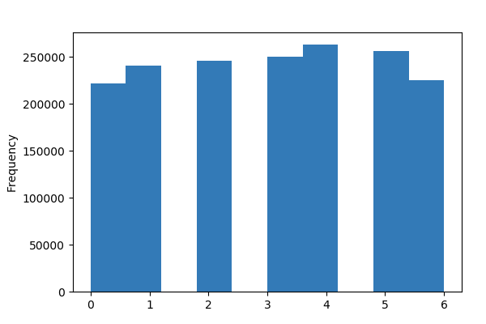

**Common Values**

| Value | Count | Frequency (%) |  |
| --- | --- | --- | --- |
| 4 | 263171 | 15.4% |  |
| 5 | 256530 | 15.1% |  |
| 3 | 250584 | 14.7% |  |
| 2 | 245842 | 14.4% |  |
| 1 | 240793 | 14.1% |  |
| 6 | 225538 | 13.2% |  |
| 0 | 221555 | 13.0% |  |

**Extreme Values**

Minimum 5 values

| Value | Count | Frequency (%) |  |
| --- | --- | --- | --- |
| 0 | 221555 | 13.0% |  |
| 1 | 240793 | 14.1% |  |
| 2 | 245842 | 14.4% |  |
| 3 | 250584 | 14.7% |  |
| 4 | 263171 | 15.4% |  |

Maximum 5 values

| Value | Count | Frequency (%) |  |
| --- | --- | --- | --- |
| 2 | 245842 | 14.4% |  |
| 3 | 250584 | 14.7% |  |
| 4 | 263171 | 15.4% |  |
| 5 | 256530 | 15.1% |  |
| 6 | 225538 | 13.2% |  |

Season  
Categorical

| Distinct count | 4 |
| --- | --- |
| Unique (%) | 0.0% |
| Missing (%) | 0.0% |
| Missing (n) | 0 |

| Spring | 453233 |
| --- | --- |
| Fall | 435330 |
| Winter | 414799 |

Toggle details

| Value | Count | Frequency (%) |  |
| --- | --- | --- | --- |
| Spring | 453233 | 26.6% |  |
| Fall | 435330 | 25.5% |  |
| Winter | 414799 | 24.3% |  |
| Summer | 400651 | 23.5% |  |

Unnamed: 0  
Highly correlated

*This variable is highly correlated with `index` and should be ignored for analysis*

| Correlation | 0.99975 |
| --- | --- |

Year  
Constant

*This variable is constant and should be ignored for analysis*

| Constant value | 2013 |
| --- | --- |

date  
Categorical

| Distinct count | 365 |
| --- | --- |
| Unique (%) | 0.0% |
| Missing (%) | 0.0% |
| Missing (n) | 0 |

| 2013-04-20 | 6152 |
| --- | --- |
| 2013-05-31 | 6035 |
| 2013-06-14 | 5954 |
| Other values (362) | 1685872 |

Toggle details

| Value | Count | Frequency (%) |  |
| --- | --- | --- | --- |
| 2013-04-20 | 6152 | 0.4% |  |
| 2013-05-31 | 6035 | 0.4% |  |
| 2013-06-14 | 5954 | 0.3% |  |
| 2013-03-09 | 5940 | 0.3% |  |
| 2013-11-01 | 5840 | 0.3% |  |
| 2013-04-05 | 5818 | 0.3% |  |
| 2013-11-02 | 5797 | 0.3% |  |
| 2013-11-23 | 5784 | 0.3% |  |
| 2013-04-19 | 5737 | 0.3% |  |
| 2013-10-18 | 5703 | 0.3% |  |
| Other values (355) | 1645253 | 96.6% |  |

datetime  
Date

| Distinct count | 8759 |
| --- | --- |
| Unique (%) | 0.5% |
| Missing (%) | 0.0% |
| Missing (n) | 0 |
| Infinite (%) | 0.0% |
| Infinite (n) | 0 |

| Minimum | 2013-01-01 00:00:00 |
| --- | --- |
| Maximum | 2013-12-31 23:00:00 |

Toggle details

daytime  
Categorical

| Distinct count | 4 |
| --- | --- |
| Unique (%) | 0.0% |
| Missing (%) | 0.0% |
| Missing (n) | 0 |

| Afternoon | 590922 |
| --- | --- |
| Morning | 425380 |
| Evening | 402999 |

Toggle details

| Value | Count | Frequency (%) |  |
| --- | --- | --- | --- |
| Afternoon | 590922 | 34.7% |  |
| Morning | 425380 | 25.0% |  |
| Evening | 402999 | 23.6% |  |
| Night | 284712 | 16.7% |  |

dropoff_datetime  
Date

| Distinct count | 1196912 |
| --- | --- |
| Unique (%) | 70.2% |
| Missing (%) | 0.0% |
| Missing (n) | 0 |
| Infinite (%) | 0.0% |
| Infinite (n) | 0 |

| Minimum | 2013-01-01 00:02:00 |
| --- | --- |
| Maximum | 2014-01-01 00:28:12 |

Toggle details

dropoff_latitude  
Highly correlated

*This variable is highly correlated with `pickup_latitude` and should be ignored for analysis*

| Correlation | 0.93111 |
| --- | --- |

dropoff_longitude  
Highly correlated

*This variable is highly correlated with `pickup_longitude` and should be ignored for analysis*

| Correlation | 0.99538 |
| --- | --- |

fare_amount  
Highly correlated

*This variable is highly correlated with `trip_distance` and should be ignored for analysis*

| Correlation | 0.90769 |
| --- | --- |

hack_license  
Categorical

| Distinct count | 23709 |
| --- | --- |
| Unique (%) | 1.4% |
| Missing (%) | 0.0% |
| Missing (n) | 0 |

| 149974E97D992C3A227ED35C5EB3AA6B | 448 |
| --- | --- |
| D99D198395EC876497BBE06F1A26E954 | 354 |
| 5BD83749A65720DA48E6DFEA47562405 | 351 |
| Other values (23706) | 1702860 |

Toggle details

| Value | Count | Frequency (%) |  |
| --- | --- | --- | --- |
| 149974E97D992C3A227ED35C5EB3AA6B | 448 | 0.0% |  |
| D99D198395EC876497BBE06F1A26E954 | 354 | 0.0% |  |
| 5BD83749A65720DA48E6DFEA47562405 | 351 | 0.0% |  |
| 7B4B3A68E8CC41CEA47AAA2295A8E61E | 338 | 0.0% |  |
| D20DFC59B81A2918082D920FAC2D01B3 | 337 | 0.0% |  |
| 676BC3464C5238DCCB33E719A5759ED4 | 336 | 0.0% |  |
| D961332334524990D1BBD462E2EFB8A4 | 336 | 0.0% |  |
| CA1E3D5BF1750AA83BAFFAC661F0E6ED | 336 | 0.0% |  |
| 89A4DDD70EF90937886A1047B8DCD5C1 | 336 | 0.0% |  |
| CE625FD96D0FAFC812A6957139B354A1 | 336 | 0.0% |  |
| Other values (23699) | 1700505 | 99.8% |  |

haversine_distances  
Numeric

| Distinct count | 1688542 |
| --- | --- |
| Unique (%) | 99.1% |
| Missing (%) | 0.0% |
| Missing (n) | 0 |
| Infinite (%) | 0.0% |
| Infinite (n) | 0 |

| Mean | 3.6117 |
| --- | --- |
| Minimum | 0 |
| Maximum | 8668 |
| Zeros (%) | 0.9% |

Toggle details

**Statistics**

Quantile statistics

| Minimum | 0 |
| --- | --- |
| 5-th percentile | 0.58254 |
| Q1 | 1.2749 |
| Median | 2.1882 |
| Q3 | 3.9781 |
| 95-th percentile | 10.292 |
| Maximum | 8668 |
| Range | 8668 |
| Interquartile range | 2.7032 |

Descriptive statistics

| Standard deviation | 34.518 |
| --- | --- |
| Coef of variation | 9.5573 |
| Kurtosis | 39266 |
| Mean | 3.6117 |
| MAD | 2.6941 |
| Skewness | 189.15 |
| Sum | 6154300 |
| Variance | 1191.5 |
| Memory size | 13.0 MiB |

**Histogram**

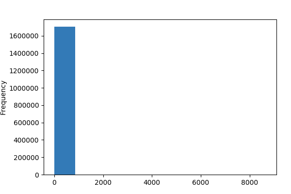

**Common Values**

| Value | Count | Frequency (%) |  |
| --- | --- | --- | --- |
| 0.0 | 14756 | 0.9% |  |
| 0.000444905369951 | 101 | 0.0% |  |
| 0.000444905370742 | 82 | 0.0% |  |
| 0.000889810740693 | 33 | 0.0% |  |
| 0.000333679027661 | 20 | 0.0% |  |
| 0.00133471611064 | 18 | 0.0% |  |
| 0.000778584397613 | 15 | 0.0% |  |
| 0.000333679028451 | 15 | 0.0% |  |
| 0.00166839513831 | 14 | 0.0% |  |
| 0.00211330050905 | 14 | 0.0% |  |
| Other values (1688532) | 1688945 | 99.1% |  |

**Extreme Values**

Minimum 5 values

| Value | Count | Frequency (%) |  |
| --- | --- | --- | --- |
| 0.0 | 14756 | 0.9% |  |
| 0.000333679026871 | 4 | 0.0% |  |
| 0.000333679027661 | 20 | 0.0% |  |
| 0.000333679028451 | 15 | 0.0% |  |
| 0.000444905369951 | 101 | 0.0% |  |

Maximum 5 values

| Value | Count | Frequency (%) |  |
| --- | --- | --- | --- |
| 8665.43198386 | 1 | 0.0% |  |
| 8665.78067661 | 1 | 0.0% |  |
| 8666.29900139 | 1 | 0.0% |  |
| 8666.72408011 | 1 | 0.0% |  |
| 8668.02616281 | 1 | 0.0% |  |

hour  
Numeric

| Distinct count | 24 |
| --- | --- |
| Unique (%) | 0.0% |
| Missing (%) | 0.0% |
| Missing (n) | 0 |
| Infinite (%) | 0.0% |
| Infinite (n) | 0 |

| Mean | 13.537 |
| --- | --- |
| Minimum | 0 |
| Maximum | 23 |
| Zeros (%) | 4.0% |

Toggle details

**Statistics**

Quantile statistics

| Minimum | 0 |
| --- | --- |
| 5-th percentile | 1 |
| Q1 | 9 |
| Median | 14 |
| Q3 | 19 |
| 95-th percentile | 22 |
| Maximum | 23 |
| Range | 23 |
| Interquartile range | 10 |

Descriptive statistics

| Standard deviation | 6.5165 |
| --- | --- |
| Coef of variation | 0.48138 |
| Kurtosis | -0.76096 |
| Mean | 13.537 |
| MAD | 5.4777 |
| Skewness | -0.44211 |
| Sum | 23067714 |
| Variance | 42.465 |
| Memory size | 13.0 MiB |

**Histogram**

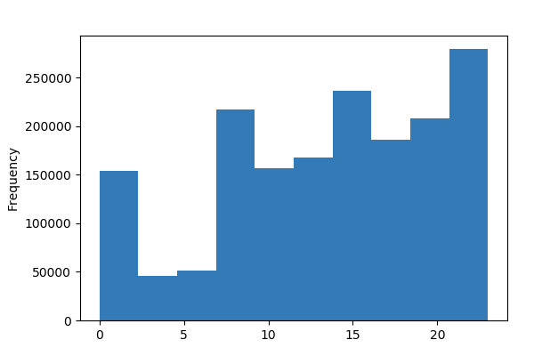

**Common Values**

| Value | Count | Frequency (%) |  |
| --- | --- | --- | --- |
| 19 | 106958 | 6.3% |  |
| 18 | 102970 | 6.0% |  |
| 20 | 101502 | 6.0% |  |
| 21 | 99122 | 5.8% |  |
| 22 | 95417 | 5.6% |  |
| 14 | 86131 | 5.1% |  |
| 23 | 84822 | 5.0% |  |
| 12 | 84472 | 5.0% |  |
| 13 | 83515 | 4.9% |  |
| 17 | 83379 | 4.9% |  |
| Other values (14) | 775725 | 45.5% |  |

**Extreme Values**

Minimum 5 values

| Value | Count | Frequency (%) |  |
| --- | --- | --- | --- |
| 0 | 67732 | 4.0% |  |
| 1 | 49763 | 2.9% |  |
| 2 | 36633 | 2.1% |  |
| 3 | 26508 | 1.6% |  |
| 4 | 19254 | 1.1% |  |

Maximum 5 values

| Value | Count | Frequency (%) |  |
| --- | --- | --- | --- |
| 19 | 106958 | 6.3% |  |
| 20 | 101502 | 6.0% |  |
| 21 | 99122 | 5.8% |  |
| 22 | 95417 | 5.6% |  |
| 23 | 84822 | 5.0% |  |

hour_total  
Constant

*This variable is constant and should be ignored for analysis*

| Constant value | 1 |
| --- | --- |

index  
Numeric

| Distinct count | 1704013 |
| --- | --- |
| Unique (%) | 100.0% |
| Missing (%) | 0.0% |
| Missing (n) | 0 |
| Infinite (%) | 0.0% |
| Infinite (n) | 0 |

| Mean | 852020 |
| --- | --- |
| Minimum | 0 |
| Maximum | 1704044 |
| Zeros (%) | 0.0% |

Toggle details

**Statistics**

Quantile statistics

| Minimum | 0 |
| --- | --- |
| 5-th percentile | 85201 |
| Q1 | 426000 |
| Median | 852010 |
| Q3 | 1278000 |
| 95-th percentile | 1618800 |
| Maximum | 1704044 |
| Range | 1704044 |
| Interquartile range | 852040 |

Descriptive statistics

| Standard deviation | 491920 |
| --- | --- |
| Coef of variation | 0.57736 |
| Kurtosis | -1.2 |
| Mean | 852020 |
| MAD | 426020 |
| Skewness | 2.2972e-05 |
| Sum | 1451849637543 |
| Variance | 241980000000 |
| Memory size | 13.0 MiB |

**Histogram**

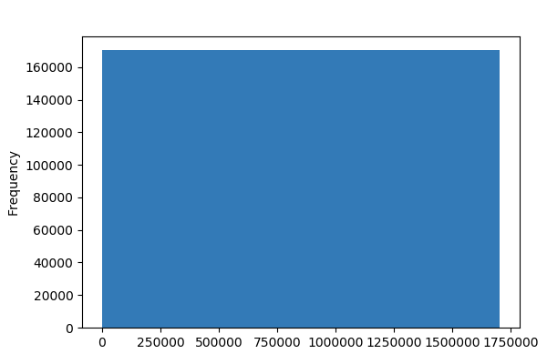

**Common Values**

| Value | Count | Frequency (%) |  |
| --- | --- | --- | --- |
| 2047 | 1 | 0.0% |  |
| 1351716 | 1 | 0.0% |  |
| 856840 | 1 | 0.0% |  |
| 858889 | 1 | 0.0% |  |
| 852746 | 1 | 0.0% |  |
| 854795 | 1 | 0.0% |  |
| 865036 | 1 | 0.0% |  |
| 867085 | 1 | 0.0% |  |
| 860942 | 1 | 0.0% |  |
| 862991 | 1 | 0.0% |  |
| Other values (1704003) | 1704003 | 100.0% |  |

**Extreme Values**

Minimum 5 values

| Value | Count | Frequency (%) |  |
| --- | --- | --- | --- |
| 0 | 1 | 0.0% |  |
| 1 | 1 | 0.0% |  |
| 2 | 1 | 0.0% |  |
| 3 | 1 | 0.0% |  |
| 4 | 1 | 0.0% |  |

Maximum 5 values

| Value | Count | Frequency (%) |  |
| --- | --- | --- | --- |
| 1704040 | 1 | 0.0% |  |
| 1704041 | 1 | 0.0% |  |
| 1704042 | 1 | 0.0% |  |
| 1704043 | 1 | 0.0% |  |
| 1704044 | 1 | 0.0% |  |

medallion  
Categorical

| Distinct count | 11845 |
| --- | --- |
| Unique (%) | 0.7% |
| Missing (%) | 0.0% |
| Missing (n) | 0 |

| 36CD8C29F77E2F6CBFFA96246F56DF76 | 665 |
| --- | --- |
| 3717C04FF182C423838EE021476A7A69 | 608 |
| 02F59ACEA8585B113601E19A3A5F4F47 | 560 |
| Other values (11842) | 1702180 |

Toggle details

| Value | Count | Frequency (%) |  |
| --- | --- | --- | --- |
| 36CD8C29F77E2F6CBFFA96246F56DF76 | 665 | 0.0% |  |
| 3717C04FF182C423838EE021476A7A69 | 608 | 0.0% |  |
| 02F59ACEA8585B113601E19A3A5F4F47 | 560 | 0.0% |  |
| 9CCF07B476B482C2050A8C63360586F7 | 560 | 0.0% |  |
| 9F1F27280ACE1C0159EAFB1A7FF03771 | 559 | 0.0% |  |
| 87EC61B520189EFEAD8FDFBABD756E4A | 546 | 0.0% |  |
| 45C1242B0114EC24F7B2FD1EE1D40C5B | 511 | 0.0% |  |
| 43FE458F8739C22C9CED57A4221148C8 | 508 | 0.0% |  |
| D978FA187038016567511C9FDF2DB955 | 505 | 0.0% |  |
| 8E3B051DF55DD1DA3FE8307D95EE4542 | 504 | 0.0% |  |
| Other values (11835) | 1698487 | 99.7% |  |

monthname  
Categorical

| Distinct count | 12 |
| --- | --- |
| Unique (%) | 0.0% |
| Missing (%) | 0.0% |
| Missing (n) | 0 |

| Mar | 156858 |
| --- | --- |
| May | 148491 |
| Apr | 147884 |
| Other values (9) | 1250780 |

Toggle details

| Value | Count | Frequency (%) |  |
| --- | --- | --- | --- |
| Mar | 156858 | 9.2% |  |
| May | 148491 | 8.7% |  |
| Apr | 147884 | 8.7% |  |
| Oct | 147242 | 8.6% |  |
| Nov | 146984 | 8.6% |  |
| Jan | 145161 | 8.5% |  |
| Jun | 143114 | 8.4% |  |
| Sep | 141104 | 8.3% |  |
| Dec | 135380 | 7.9% |  |
| Jul | 134811 | 7.9% |  |
| Other values (2) | 256984 | 15.1% |  |

monthnumber  
Highly correlated

*This variable is highly correlated with `Unnamed: 0` and should be ignored for analysis*

| Correlation | 0.99661 |
| --- | --- |

mta_tax  
Boolean

| Distinct count | 2 |
| --- | --- |
| Unique (%) | 0.0% |
| Missing (%) | 0.0% |
| Missing (n) | 0 |

| Mean | 0.49843 |
| --- | --- |

| 0.5 | 1698664 |
| --- | --- |
| 0.0 | 5349 |

Toggle details

| Value | Count | Frequency (%) |  |
| --- | --- | --- | --- |
| 0.5 | 1698664 | 99.7% |  |
| 0.0 | 5349 | 0.3% |  |

passenger_count  
Numeric

| Distinct count | 8 |
| --- | --- |
| Unique (%) | 0.0% |
| Missing (%) | 0.0% |
| Missing (n) | 0 |
| Infinite (%) | 0.0% |
| Infinite (n) | 0 |

| Mean | 1.7131 |
| --- | --- |
| Minimum | 0 |
| Maximum | 8 |
| Zeros (%) | 0.0% |

Toggle details

**Statistics**

Quantile statistics

| Minimum | 0 |
| --- | --- |
| 5-th percentile | 1 |
| Q1 | 1 |
| Median | 1 |
| Q3 | 2 |
| 95-th percentile | 5 |
| Maximum | 8 |
| Range | 8 |
| Interquartile range | 1 |

Descriptive statistics

| Standard deviation | 1.3801 |
| --- | --- |
| Coef of variation | 0.80564 |
| Kurtosis | 2.807 |
| Mean | 1.7131 |
| MAD | 1.0041 |
| Skewness | 2.0074 |
| Sum | 2919169 |
| Variance | 1.9048 |
| Memory size | 13.0 MiB |

**Histogram**

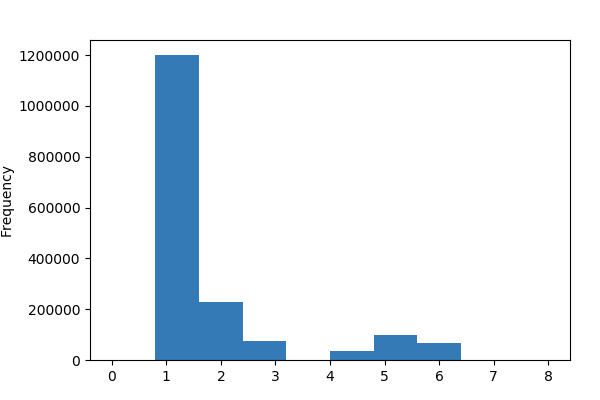

**Common Values**

| Value | Count | Frequency (%) |  |
| --- | --- | --- | --- |
| 1 | 1199586 | 70.4% |  |
| 2 | 229507 | 13.5% |  |
| 5 | 97769 | 5.7% |  |
| 3 | 72998 | 4.3% |  |
| 6 | 68075 | 4.0% |  |
| 4 | 36068 | 2.1% |  |
| 0 | 9 | 0.0% |  |
| 8 | 1 | 0.0% |  |

**Extreme Values**

Minimum 5 values

| Value | Count | Frequency (%) |  |
| --- | --- | --- | --- |
| 0 | 9 | 0.0% |  |
| 1 | 1199586 | 70.4% |  |
| 2 | 229507 | 13.5% |  |
| 3 | 72998 | 4.3% |  |
| 4 | 36068 | 2.1% |  |

Maximum 5 values

| Value | Count | Frequency (%) |  |
| --- | --- | --- | --- |
| 3 | 72998 | 4.3% |  |
| 4 | 36068 | 2.1% |  |
| 5 | 97769 | 5.7% |  |
| 6 | 68075 | 4.0% |  |
| 8 | 1 | 0.0% |  |

payment_type  
Categorical

| Distinct count | 5 |
| --- | --- |
| Unique (%) | 0.0% |
| Missing (%) | 0.0% |
| Missing (n) | 0 |

| CRD | 918686 |
| --- | --- |
| CSH | 778213 |
| NOC | 4025 |
| Other values (2) | 3089 |

Toggle details

| Value | Count | Frequency (%) |  |
| --- | --- | --- | --- |
| CRD | 918686 | 53.9% |  |
| CSH | 778213 | 45.7% |  |
| NOC | 4025 | 0.2% |  |
| UNK | 1917 | 0.1% |  |
| DIS | 1172 | 0.1% |  |

pickup_datetime  
Date

| Distinct count | 1196301 |
| --- | --- |
| Unique (%) | 70.2% |
| Missing (%) | 0.0% |
| Missing (n) | 0 |
| Infinite (%) | 0.0% |
| Infinite (n) | 0 |

| Minimum | 2013-01-01 00:00:16 |
| --- | --- |
| Maximum | 2013-12-31 23:59:22 |

Toggle details

pickup_latitude  
Numeric

| Distinct count | 49879 |
| --- | --- |
| Unique (%) | 2.9% |
| Missing (%) | 0.0% |
| Missing (n) | 0 |
| Infinite (%) | 0.0% |
| Infinite (n) | 0 |

| Mean | 40.4 |
| --- | --- |
| Minimum | -3181.1 |
| Maximum | 73.994 |
| Zeros (%) | 0.0% |

Toggle details

**Statistics**

Quantile statistics

| Minimum | -3181.1 |
| --- | --- |
| 5-th percentile | 40.708 |
| Q1 | 40.736 |
| Median | 40.753 |
| Q3 | 40.767 |
| 95-th percentile | 40.788 |
| Maximum | 73.994 |
| Range | 3255.1 |
| Interquartile range | 0.031441 |

Descriptive statistics

| Standard deviation | 6.7817 |
| --- | --- |
| Coef of variation | 0.16786 |
| Kurtosis | 30125 |
| Mean | 40.4 |
| MAD | 0.69984 |
| Skewness | -77.488 |
| Sum | 68842000 |
| Variance | 45.991 |
| Memory size | 13.0 MiB |

**Histogram**

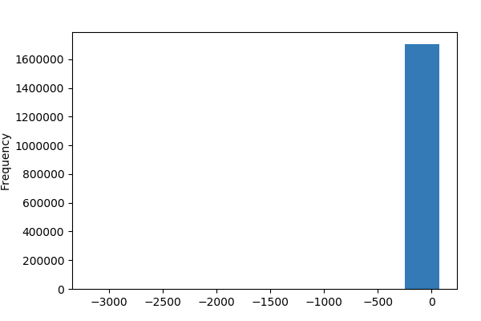

**Common Values**

| Value | Count | Frequency (%) |  |
| --- | --- | --- | --- |
| 40.774078 | 351 | 0.0% |  |
| 40.774109 | 313 | 0.0% |  |
| 40.77412 | 313 | 0.0% |  |
| 40.774094 | 312 | 0.0% |  |
| 40.774117 | 307 | 0.0% |  |
| 40.774101 | 306 | 0.0% |  |
| 40.774036 | 288 | 0.0% |  |
| 40.774071 | 288 | 0.0% |  |
| 40.774063 | 284 | 0.0% |  |
| 40.774055 | 278 | 0.0% |  |
| Other values (49869) | 1700973 | 99.8% |  |

**Extreme Values**

Minimum 5 values

| Value | Count | Frequency (%) |  |
| --- | --- | --- | --- |
| -3181.0781 | 1 | 0.0% |  |
| -74.152069 | 1 | 0.0% |  |
| -74.017693 | 1 | 0.0% |  |
| -74.017326 | 1 | 0.0% |  |
| -74.017204 | 1 | 0.0% |  |

Maximum 5 values

| Value | Count | Frequency (%) |  |
| --- | --- | --- | --- |
| 48.049999 | 1 | 0.0% |  |
| 48.083332 | 1 | 0.0% |  |
| 48.566666 | 1 | 0.0% |  |
| 50.066666 | 1 | 0.0% |  |
| 73.994064 | 1 | 0.0% |  |

pickup_longitude  
Numeric

| Distinct count | 27980 |
| --- | --- |
| Unique (%) | 1.6% |
| Missing (%) | 0.0% |
| Missing (n) | 0 |
| Infinite (%) | 0.0% |
| Infinite (n) | 0 |

| Mean | -73.626 |
| --- | --- |
| Minimum | -735.21 |
| Maximum | 40.993 |
| Zeros (%) | 0.0% |

Toggle details

**Statistics**

Quantile statistics

| Minimum | -735.21 |
| --- | --- |
| 5-th percentile | -74.007 |
| Q1 | -73.992 |
| Median | -73.982 |
| Q3 | -73.968 |
| 95-th percentile | -73.928 |
| Maximum | 40.993 |
| Range | 776.2 |
| Interquartile range | 0.024453 |

Descriptive statistics

| Standard deviation | 6.341 |
| --- | --- |
| Coef of variation | -0.086125 |
| Kurtosis | 388.52 |
| Mean | -73.626 |
| MAD | 0.69717 |
| Skewness | 17.19 |
| Sum | -125460000 |
| Variance | 40.208 |
| Memory size | 13.0 MiB |

**Histogram**

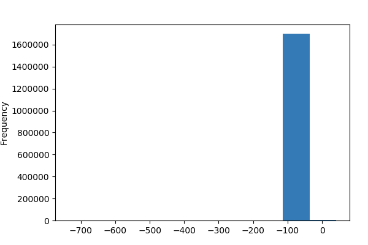

**Common Values**

| Value | Count | Frequency (%) |  |
| --- | --- | --- | --- |
| -73.982208 | 706 | 0.0% |  |
| -73.982239 | 660 | 0.0% |  |
| -73.982224 | 642 | 0.0% |  |
| -73.982117 | 629 | 0.0% |  |
| -73.982079 | 626 | 0.0% |  |
| -73.982201 | 626 | 0.0% |  |
| -73.982346 | 599 | 0.0% |  |
| -73.982124 | 598 | 0.0% |  |
| -73.982262 | 595 | 0.0% |  |
| -73.9823 | 589 | 0.0% |  |
| Other values (27970) | 1697743 | 99.6% |  |

**Extreme Values**

Minimum 5 values

| Value | Count | Frequency (%) |  |
| --- | --- | --- | --- |
| -735.20667 | 1 | 0.0% |  |
| -106.11467 | 1 | 0.0% |  |
| -95.099998 | 1 | 0.0% |  |
| -93.866669 | 1 | 0.0% |  |
| -92.237656 | 1 | 0.0% |  |

Maximum 5 values

| Value | Count | Frequency (%) |  |
| --- | --- | --- | --- |
| 40.834236 | 1 | 0.0% |  |
| 40.841606 | 1 | 0.0% |  |
| 40.854622 | 1 | 0.0% |  |
| 40.907318 | 1 | 0.0% |  |
| 40.99329 | 1 | 0.0% |  |

pickup_month  
Highly correlated

*This variable is highly correlated with `monthnumber` and should be ignored for analysis*

| Correlation | 1 |
| --- | --- |

pickup_weekday_name  
Categorical

| Distinct count | 7 |
| --- | --- |
| Unique (%) | 0.0% |
| Missing (%) | 0.0% |
| Missing (n) | 0 |

| Friday | 263171 |
| --- | --- |
| Saturday | 256530 |
| Thursday | 250584 |
| Other values (4) | 933728 |

Toggle details

| Value | Count | Frequency (%) |  |
| --- | --- | --- | --- |
| Friday | 263171 | 15.4% |  |
| Saturday | 256530 | 15.1% |  |
| Thursday | 250584 | 14.7% |  |
| Wednesday | 245842 | 14.4% |  |
| Tuesday | 240793 | 14.1% |  |
| Sunday | 225538 | 13.2% |  |
| Monday | 221555 | 13.0% |  |

rate_code  
Numeric

| Distinct count | 9 |
| --- | --- |
| Unique (%) | 0.0% |
| Missing (%) | 0.0% |
| Missing (n) | 0 |
| Infinite (%) | 0.0% |
| Infinite (n) | 0 |

| Mean | 1.0305 |
| --- | --- |
| Minimum | 0 |
| Maximum | 210 |
| Zeros (%) | 0.0% |

Toggle details

**Statistics**

Quantile statistics

| Minimum | 0 |
| --- | --- |
| 5-th percentile | 1 |
| Q1 | 1 |
| Median | 1 |
| Q3 | 1 |
| 95-th percentile | 1 |
| Maximum | 210 |
| Range | 210 |
| Interquartile range | 0 |

Descriptive statistics

| Standard deviation | 0.33433 |
| --- | --- |
| Coef of variation | 0.32444 |
| Kurtosis | 179170 |
| Mean | 1.0305 |
| MAD | 0.059977 |
| Skewness | 291.13 |
| Sum | 1755995 |
| Variance | 0.11178 |
| Memory size | 13.0 MiB |

**Histogram**

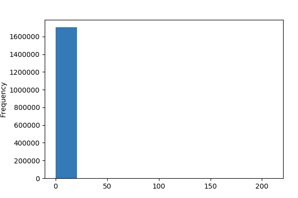

**Common Values**

| Value | Count | Frequency (%) |  |
| --- | --- | --- | --- |
| 1 | 1666928 | 97.8% |  |
| 2 | 29801 | 1.7% |  |
| 5 | 3375 | 0.2% |  |
| 3 | 2521 | 0.1% |  |
| 4 | 1126 | 0.1% |  |
| 0 | 243 | 0.0% |  |
| 6 | 16 | 0.0% |  |
| 210 | 2 | 0.0% |  |
| 7 | 1 | 0.0% |  |

**Extreme Values**

Minimum 5 values

| Value | Count | Frequency (%) |  |
| --- | --- | --- | --- |
| 0 | 243 | 0.0% |  |
| 1 | 1666928 | 97.8% |  |
| 2 | 29801 | 1.7% |  |
| 3 | 2521 | 0.1% |  |
| 4 | 1126 | 0.1% |  |

Maximum 5 values

| Value | Count | Frequency (%) |  |
| --- | --- | --- | --- |
| 4 | 1126 | 0.1% |  |
| 5 | 3375 | 0.2% |  |
| 6 | 16 | 0.0% |  |
| 7 | 1 | 0.0% |  |
| 210 | 2 | 0.0% |  |

store_and_fwd_flag  
Boolean

| Distinct count | 2 |
| --- | --- |
| Unique (%) | 0.0% |
| Missing (%) | 0.0% |
| Missing (n) | 0 |

| Mean | 0.011566 |
| --- | --- |

| 0 | 1684304 |
| --- | --- |
| 1 | 19709 |

Toggle details

| Value | Count | Frequency (%) |  |
| --- | --- | --- | --- |
| 0 | 1684304 | 98.8% |  |
| 1 | 19709 | 1.2% |  |

surcharge  
Numeric

| Distinct count | 9 |
| --- | --- |
| Unique (%) | 0.0% |
| Missing (%) | 0.0% |
| Missing (n) | 0 |
| Infinite (%) | 0.0% |
| Infinite (n) | 0 |

| Mean | 0.3198 |
| --- | --- |
| Minimum | 0 |
| Maximum | 5.5 |
| Zeros (%) | 50.7% |

Toggle details

**Statistics**

Quantile statistics

| Minimum | 0 |
| --- | --- |
| 5-th percentile | 0 |
| Q1 | 0 |
| Median | 0 |
| Q3 | 0.5 |
| 95-th percentile | 1 |
| Maximum | 5.5 |
| Range | 5.5 |
| Interquartile range | 0.5 |

Descriptive statistics

| Standard deviation | 0.36198 |
| --- | --- |
| Coef of variation | 1.1319 |
| Kurtosis | -0.81367 |
| Mean | 0.3198 |
| MAD | 0.32438 |
| Skewness | 0.66881 |
| Sum | 544940 |
| Variance | 0.13103 |
| Memory size | 13.0 MiB |

**Histogram**

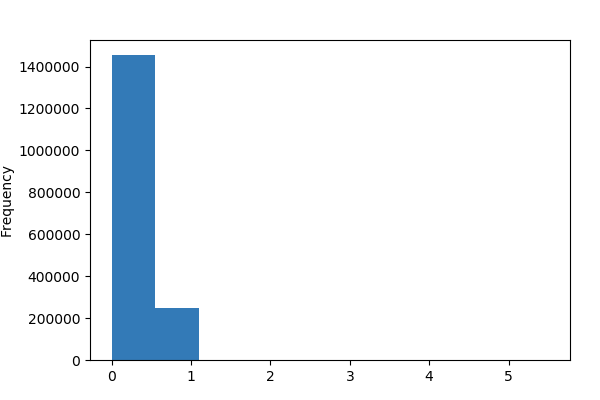

**Common Values**

| Value | Count | Frequency (%) |  |
| --- | --- | --- | --- |
| 0.0 | 864222 | 50.7% |  |
| 0.5 | 589725 | 34.6% |  |
| 1.0 | 250048 | 14.7% |  |
| 1.5 | 8 | 0.0% |  |
| 2.0 | 5 | 0.0% |  |
| 0.82 | 2 | 0.0% |  |
| 0.41 | 1 | 0.0% |  |
| 5.5 | 1 | 0.0% |  |
| 1.23 | 1 | 0.0% |  |

**Extreme Values**

Minimum 5 values

| Value | Count | Frequency (%) |  |
| --- | --- | --- | --- |
| 0.0 | 864222 | 50.7% |  |
| 0.41 | 1 | 0.0% |  |
| 0.5 | 589725 | 34.6% |  |
| 0.82 | 2 | 0.0% |  |
| 1.0 | 250048 | 14.7% |  |

Maximum 5 values

| Value | Count | Frequency (%) |  |
| --- | --- | --- | --- |
| 1.0 | 250048 | 14.7% |  |
| 1.23 | 1 | 0.0% |  |
| 1.5 | 8 | 0.0% |  |
| 2.0 | 5 | 0.0% |  |
| 5.5 | 1 | 0.0% |  |

temperature  
Numeric

| Distinct count | 4304 |
| --- | --- |
| Unique (%) | 0.3% |
| Missing (%) | 0.0% |
| Missing (n) | 0 |
| Infinite (%) | 0.0% |
| Infinite (n) | 0 |

| Mean | 285.57 |
| --- | --- |
| Minimum | 261.22 |
| Maximum | 310.24 |
| Zeros (%) | 0.0% |

Toggle details

**Statistics**

Quantile statistics

| Minimum | 261.22 |
| --- | --- |
| 5-th percentile | 270.33 |
| Q1 | 277.18 |
| Median | 285.25 |
| Q3 | 293.64 |
| 95-th percentile | 301.78 |
| Maximum | 310.24 |
| Range | 49.02 |
| Interquartile range | 16.46 |

Descriptive statistics

| Standard deviation | 10.062 |
| --- | --- |
| Coef of variation | 0.035235 |
| Kurtosis | -0.90062 |
| Mean | 285.57 |
| MAD | 8.5877 |
| Skewness | 0.079218 |
| Sum | 486610000 |
| Variance | 101.24 |
| Memory size | 13.0 MiB |

**Histogram**

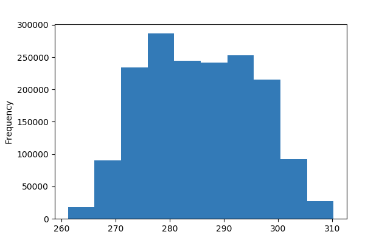

**Common Values**

| Value | Count | Frequency (%) |  |
| --- | --- | --- | --- |
| 297.15 | 3259 | 0.2% |  |
| 284.793 | 2531 | 0.1% |  |
| 276.47 | 2432 | 0.1% |  |
| 296.35 | 2404 | 0.1% |  |
| 293.85 | 2281 | 0.1% |  |
| 288.45 | 2140 | 0.1% |  |
| 290.45 | 1974 | 0.1% |  |
| 290.85 | 1954 | 0.1% |  |
| 291.85 | 1903 | 0.1% |  |
| 292.35 | 1892 | 0.1% |  |
| Other values (4294) | 1681243 | 98.7% |  |

**Extreme Values**

Minimum 5 values

| Value | Count | Frequency (%) |  |
| --- | --- | --- | --- |
| 261.22 | 214 | 0.0% |  |
| 261.27 | 221 | 0.0% |  |
| 261.31 | 291 | 0.0% |  |
| 261.45 | 282 | 0.0% |  |
| 261.475 | 246 | 0.0% |  |

Maximum 5 values

| Value | Count | Frequency (%) |  |
| --- | --- | --- | --- |
| 309.37 | 290 | 0.0% |  |
| 309.62 | 213 | 0.0% |  |
| 309.7 | 187 | 0.0% |  |
| 309.82 | 223 | 0.0% |  |
| 310.24 | 244 | 0.0% |  |

tip_amount  
Numeric

| Distinct count | 1744 |
| --- | --- |
| Unique (%) | 0.1% |
| Missing (%) | 0.0% |
| Missing (n) | 0 |
| Infinite (%) | 0.0% |
| Infinite (n) | 0 |

| Mean | 1.3616 |
| --- | --- |
| Minimum | 0 |
| Maximum | 180 |
| Zeros (%) | 47.6% |

Toggle details

**Statistics**

Quantile statistics

| Minimum | 0 |
| --- | --- |
| 5-th percentile | 0 |
| Q1 | 0 |
| Median | 1 |
| Q3 | 2 |
| 95-th percentile | 5 |
| Maximum | 180 |
| Range | 180 |
| Interquartile range | 2 |

Descriptive statistics

| Standard deviation | 2.1653 |
| --- | --- |
| Coef of variation | 1.5903 |
| Kurtosis | 192.52 |
| Mean | 1.3616 |
| MAD | 1.3936 |
| Skewness | 6.265 |
| Sum | 2320200 |
| Variance | 4.6886 |
| Memory size | 13.0 MiB |

**Histogram**

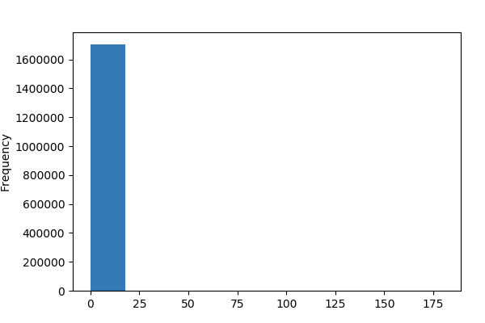

**Common Values**

| Value | Count | Frequency (%) |  |
| --- | --- | --- | --- |
| 0.0 | 811324 | 47.6% |  |
| 1.0 | 150208 | 8.8% |  |
| 2.0 | 83650 | 4.9% |  |
| 1.5 | 66508 | 3.9% |  |
| 3.0 | 29017 | 1.7% |  |
| 2.5 | 24162 | 1.4% |  |
| 1.8 | 21173 | 1.2% |  |
| 1.6 | 20026 | 1.2% |  |
| 1.4 | 19861 | 1.2% |  |
| 1.3 | 19181 | 1.1% |  |
| Other values (1734) | 458903 | 26.9% |  |

**Extreme Values**

Minimum 5 values

| Value | Count | Frequency (%) |  |
| --- | --- | --- | --- |
| 0.0 | 811324 | 47.6% |  |
| 0.01 | 460 | 0.0% |  |
| 0.02 | 152 | 0.0% |  |
| 0.03 | 49 | 0.0% |  |
| 0.04 | 18 | 0.0% |  |

Maximum 5 values

| Value | Count | Frequency (%) |  |
| --- | --- | --- | --- |
| 150.08 | 1 | 0.0% |  |
| 150.15 | 1 | 0.0% |  |
| 160.0 | 1 | 0.0% |  |
| 177.5 | 1 | 0.0% |  |
| 180.0 | 1 | 0.0% |  |

tolls_amount  
Numeric

| Distinct count | 258 |
| --- | --- |
| Unique (%) | 0.0% |
| Missing (%) | 0.0% |
| Missing (n) | 0 |
| Infinite (%) | 0.0% |
| Infinite (n) | 0 |

| Mean | 0.25097 |
| --- | --- |
| Minimum | 0 |
| Maximum | 99 |
| Zeros (%) | 95.5% |

Toggle details

**Statistics**

Quantile statistics

| Minimum | 0 |
| --- | --- |
| 5-th percentile | 0 |
| Q1 | 0 |
| Median | 0 |
| Q3 | 0 |
| 95-th percentile | 0 |
| Maximum | 99 |
| Range | 99 |
| Interquartile range | 0 |

Descriptive statistics

| Standard deviation | 1.2013 |
| --- | --- |
| Coef of variation | 4.7867 |
| Kurtosis | 89.475 |
| Mean | 0.25097 |
| MAD | 0.47921 |
| Skewness | 5.9445 |
| Sum | 427660 |
| Variance | 1.4432 |
| Memory size | 13.0 MiB |

**Histogram**

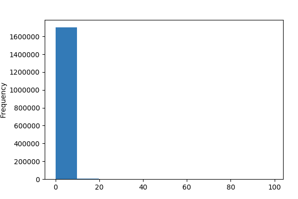

**Common Values**

| Value | Count | Frequency (%) |  |
| --- | --- | --- | --- |
| 0.0 | 1626838 | 95.5% |  |
| 5.33 | 60966 | 3.6% |  |
| 4.8 | 11018 | 0.6% |  |
| 10.25 | 1542 | 0.1% |  |
| 8.25 | 606 | 0.0% |  |
| 2.44 | 561 | 0.0% |  |
| 10.66 | 354 | 0.0% |  |
| 11.0 | 145 | 0.0% |  |
| 2.2 | 126 | 0.0% |  |
| 15.58 | 116 | 0.0% |  |
| Other values (248) | 1741 | 0.1% |  |

**Extreme Values**

Minimum 5 values

| Value | Count | Frequency (%) |  |
| --- | --- | --- | --- |
| 0.0 | 1626838 | 95.5% |  |
| 0.01 | 8 | 0.0% |  |
| 0.04 | 2 | 0.0% |  |
| 0.05 | 3 | 0.0% |  |
| 0.09 | 1 | 0.0% |  |

Maximum 5 values

| Value | Count | Frequency (%) |  |
| --- | --- | --- | --- |
| 29.52 | 1 | 0.0% |  |
| 50.33 | 1 | 0.0% |  |
| 60.0 | 1 | 0.0% |  |
| 97.0 | 1 | 0.0% |  |
| 99.0 | 1 | 0.0% |  |

total_amount  
Highly correlated

*This variable is highly correlated with `fare_amount` and should be ignored for analysis*

| Correlation | 0.98294 |
| --- | --- |

trip_distance  
Numeric

| Distinct count | 3037 |
| --- | --- |
| Unique (%) | 0.2% |
| Missing (%) | 0.0% |
| Missing (n) | 0 |
| Infinite (%) | 0.0% |
| Infinite (n) | 0 |

| Mean | 2.8937 |
| --- | --- |
| Minimum | 0 |
| Maximum | 318 |
| Zeros (%) | 0.5% |

Toggle details

**Statistics**

Quantile statistics

| Minimum | 0 |
| --- | --- |
| 5-th percentile | 0.5 |
| Q1 | 1.05 |
| Median | 1.8 |
| Q3 | 3.2 |
| 95-th percentile | 9.86 |
| Maximum | 318 |
| Range | 318 |
| Interquartile range | 2.15 |

Descriptive statistics

| Standard deviation | 3.4041 |
| --- | --- |
| Coef of variation | 1.1764 |
| Kurtosis | 97.876 |
| Mean | 2.8937 |
| MAD | 2.1176 |
| Skewness | 4.1754 |
| Sum | 4931000 |
| Variance | 11.588 |
| Memory size | 13.0 MiB |

**Histogram**

[4 more figures not shown]

Sample

|  | medallion | hack_license | vendor_id | rate_code | store_and_fwd_flag | pickup_datetime | dropoff_datetime | passenger_count | trip_time_in_secs | trip_distance | pickup_longitude | pickup_latitude | dropoff_longitude | dropoff_latitude | payment_type | fare_amount | surcharge | mta_tax | tolls_amount | total_amount | tip_amount | Year | DOW | pickup_weekday_name | hour | date | Unnamed: 0 | datetime | temperature | … |
| --- | --- | --- | --- | --- | --- | --- | --- | --- | --- | --- | --- | --- | --- | --- | --- | --- | --- | --- | --- | --- | --- | --- | --- | --- | --- | --- | --- | --- | --- | --- |
| 0 | 00E67F2CAC914F384C9803F02C7F85D9 | D33D2B6EB5B863CF167D251FEADFF165 | VTS | 1 | 0 | 2013-01-01 00:20:00 | 2013-01-01 00:30:00 | 4 | 600 | 2.47 | -74.003036 | 40.728607 | -74.013618 | 40.702343 | CSH | 10.5 | 0.5 | 0.5 | 0.0 | 11.5 | 0.0 | 2013 | 1 | Tuesday | 0 | 2013-01-01 | 0 | 2013-01-01 | 272.03 | … |
| 1 | 00E67F2CAC914F384C9803F02C7F85D9 | D33D2B6EB5B863CF167D251FEADFF165 | VTS | 1 | 0 | 2013-01-01 00:34:00 | 2013-01-01 00:48:00 | 5 | 840 | 4.71 | -74.009636 | 40.705952 | -73.983864 | 40.743999 | CSH | 16.5 | 0.5 | 0.5 | 0.0 | 17.5 | 0.0 | 2013 | 1 | Tuesday | 0 | 2013-01-01 | 0 | 2013-01-01 | 272.03 | … |
| 2 | 00E67F2CAC914F384C9803F02C7F85D9 | D33D2B6EB5B863CF167D251FEADFF165 | VTS | 1 | 0 | 2013-01-01 00:51:00 | 2013-01-01 01:03:00 | 4 | 720 | 2.18 | -73.987564 | 40.744373 | -73.980751 | 40.722565 | CSH | 10.0 | 0.5 | 0.5 | 0.0 | 11.0 | 0.0 | 2013 | 1 | Tuesday | 0 | 2013-01-01 | 0 | 2013-01-01 | 272.03 | … |
| 3 | 059E5BF1D421092E005D3A74304CEED3 | D8AA5AEE5F1CBB3897197CAA992902F4 | VTS | 1 | 0 | 2013-01-01 00:34:00 | 2013-01-01 00:40:00 | 1 | 360 | 0.25 | -73.977135 | 40.758957 | -73.997597 | 40.751633 | CSH | 5.0 | 0.5 | 0.5 | 0.0 | 6.0 | 0.0 | 2013 | 1 | Tuesday | 0 | 2013-01-01 | 0 | 2013-01-01 | 272.03 | … |
| 4 | 059E5BF1D421092E005D3A74304CEED3 | D8AA5AEE5F1CBB3897197CAA992902F4 | VTS | 1 | 0 | 2013-01-01 00:19:00 | 2013-01-01 00:34:00 | 1 | 900 | 1.36 | -73.977135 | 40.758957 | -73.992928 | 40.754498 | CSH | 10.0 | 0.5 | 0.5 | 0.0 | 11.0 | 0.0 | 2013 | 1 | Tuesday | 0 | 2013-01-01 | 0 | 2013-01-01 | 272.03 | … |

```python
# Find profile report
import pandas_profiling
pandas_profiling.ProfileReport(TripFareWeatherData)
```

```python
TripFareWeatherData.info()
```

```
<class 'pandas.core.frame.DataFrame'>
Int64Index: 1704013 entries, 0 to 1704044
Data columns (total 39 columns):
medallion              object
hack_license           object
vendor_id              object
rate_code              int64
store_and_fwd_flag     int64
pickup_datetime        datetime64[ns]
dropoff_datetime       datetime64[ns]
passenger_count        int64
trip_time_in_secs      int64
trip_distance          float64
pickup_longitude       float64
pickup_latitude        float64
dropoff_longitude      float64
dropoff_latitude       float64
payment_type           object
fare_amount            float64
surcharge              float64
mta_tax                float64
tolls_amount           float64
total_amount           float64
tip_amount             float64
Year                   int64
DOW                    int64
pickup_weekday_name    object
hour                   int64
date                   object
Unnamed: 0             int64
datetime               datetime64[ns]
temperature            float64
year                   int64
monthnumber            int64
monthname              object
weatherdescription     object
weather_type           object
daytime                object
Season                 object
hour_total             int64
pickup_month           int64
haversine_distances    float64
dtypes: datetime64[ns](3), float64(13), int64(12), object(11)
memory usage: 600.0+ MB
```

```python
# Copy the TripFareWeather data
OriginalTripFareWeatherData = TripFareWeatherData.copy()
```

#### Describe the needed features

```python
target_label = 'trip_time_in_secs'
#non_features = ['medallion','hack_license','Unnamed: 0', 'dropoff_datetime','datetime','mta_tax','year','hour_total','weatherdescription', 'surcharge','tolls_amount','store_and_fwd_flag','temperature','total_amount','Year','date','monthnumber','pickup_datetime','Drop_DOW', 'dropoff_datetime','dropoff_latitude','dropoff_longitude']
non_features = ['medallion','hack_license','Unnamed: 0','hour_total', 'monthnumber','date','datetime','total_amount','year','Year','pickup_datetime','dropoff_datetime','mta_tax','tolls_amount']
feature_labels = [x for x in TripFareWeatherData.columns if x not in [target_label] + non_features ]
print("All important features are ", feature_labels)
```

[output not shown]

```python
#### We will remove all not required features
```

```python
print("Removing this not necessary features", non_features)
# Filter out non-features and non-targets
TripFareWeatherData = TripFareWeatherData.drop(non_features, axis=1)
```

```
Removing this not necessary features ['medallion', 'hack_license', 'Unnamed: 0', 'hour_total', 'monthnumber', 'date', 'datetime', 'total_amount', 'year', 'Year', 'pickup_datetime', 'dropoff_datetime', 'mta_tax', 'tolls_amount']
```

```python
obj_cols = TripFareWeatherData.select_dtypes(include=["object"]).columns
obj_cols
```

```
Index(['vendor_id', 'payment_type', 'pickup_weekday_name', 'monthname',
       'weatherdescription', 'weather_type', 'daytime', 'Season'],
      dtype='object')
```

```python
# One-hot encode inputs
#house_df_expanded = pd.get_dummies(house_df, drop_first=True)
TripFareWeatherData_Expanded = pd.get_dummies(TripFareWeatherData, columns=obj_cols,drop_first=True)
print('DataFrame one-hot-expanded shape: {}'.format(TripFareWeatherData_Expanded.shape))
```

```
DataFrame one-hot-expanded shape: (1704013, 74)
```

```python
## Ensuring that all data is in Numeric format One hot encoding produces 74 following columns
```

```python
TripFareWeatherData_Expanded.info()
```

```
<class 'pandas.core.frame.DataFrame'>
Int64Index: 1704013 entries, 0 to 1704044
Data columns (total 74 columns):
rate_code                                          int64
store_and_fwd_flag                                 int64
passenger_count                                    int64
trip_time_in_secs                                  int64
trip_distance                                      float64
pickup_longitude                                   float64
pickup_latitude                                    float64
dropoff_longitude                                  float64
dropoff_latitude                                   float64
fare_amount                                        float64
surcharge                                          float64
tip_amount                                         float64
DOW                                                int64
hour                                               int64
temperature                                        float64
pickup_month                                       int64
haversine_distances                                float64
vendor_id_VTS                                      uint8
payment_type_CSH                                   uint8
payment_type_DIS                                   uint8
payment_type_NOC                                   uint8
payment_type_UNK                                   uint8
pickup_weekday_name_Monday                         uint8
pickup_weekday_name_Saturday                       uint8
pickup_weekday_name_Sunday                         uint8
pickup_weekday_name_Thursday                       uint8
pickup_weekday_name_Tuesday                        uint8
pickup_weekday_name_Wednesday                      uint8
monthname_Aug                                      uint8
monthname_Dec                                      uint8
monthname_Feb                                      uint8
monthname_Jan                                      uint8
monthname_Jul                                      uint8
monthname_Jun                                      uint8
monthname_Mar                                      uint8
monthname_May                                      uint8
monthname_Nov                                      uint8
```

[output cut: 24 more lines]

```
weatherdescription_thunderstorm with light rain    uint8
weatherdescription_thunderstorm with rain          uint8
weatherdescription_very heavy rain                 uint8
weather_type_Cloudy                                uint8
weather_type_Fog                                   uint8
weather_type_Rainy                                 uint8
weather_type_Snowy                                 uint8
daytime_Evening                                    uint8
daytime_Morning                                    uint8
daytime_Night                                      uint8
Season_Spring                                      uint8
Season_Summer                                      uint8
Season_Winter                                      uint8
dtypes: float64(10), int64(7), uint8(57)
memory usage: 406.6 MB
```

```python
TripFareWeatherData_Expanded.head()
```

[output not shown]

## Data Models

```python
sample_data=TripFareWeatherData_Expanded.sample(n=340800,replace="False")
sample_data.shape
# Get target and original x-matrix
# split dataset into training and testing
features = sample_data.loc[:, TripFareWeatherData_Expanded.columns!= 'trip_time_in_secs']
target = sample_data.loc[:,['trip_time_in_secs']]
```

```python
# Get target and original x-matrix
# split dataset into training and testing
features = TripFareWeatherData_Expanded.loc[:, TripFareWeatherData_Expanded.columns!= 'trip_time_in_secs']
target = TripFareWeatherData_Expanded.loc[:,['trip_time_in_secs']]
```

```python
features.head()
```

|  | rate_code | store_and_fwd_flag | passenger_count | trip_distance | pickup_longitude | pickup_latitude | dropoff_longitude | dropoff_latitude | fare_amount | surcharge | ... | weather_type_Cloudy | weather_type_Fog | weather_type_Rainy | weather_type_Snowy | daytime_Evening | daytime_Morning | daytime_Night | Season_Spring | Season_Summer | Season_Winter |
| --- | --- | --- | --- | --- | --- | --- | --- | --- | --- | --- | --- | --- | --- | --- | --- | --- | --- | --- | --- | --- | --- |
| 0 | 1 | 0 | 4 | 2.47 | -74.003036 | 40.728607 | -74.013618 | 40.702343 | 10.5 | 0.5 | ... | 1 | 0 | 0 | 0 | 0 | 0 | 1 | 0 | 0 | 1 |
| 1 | 1 | 0 | 5 | 4.71 | -74.009636 | 40.705952 | -73.983864 | 40.743999 | 16.5 | 0.5 | ... | 1 | 0 | 0 | 0 | 0 | 0 | 1 | 0 | 0 | 1 |
| 2 | 1 | 0 | 4 | 2.18 | -73.987564 | 40.744373 | -73.980751 | 40.722565 | 10.0 | 0.5 | ... | 1 | 0 | 0 | 0 | 0 | 0 | 1 | 0 | 0 | 1 |
| 3 | 1 | 0 | 1 | 0.25 | -73.977135 | 40.758957 | -73.997597 | 40.751633 | 5.0 | 0.5 | ... | 1 | 0 | 0 | 0 | 0 | 0 | 1 | 0 | 0 | 1 |
| 4 | 1 | 0 | 1 | 1.36 | -73.977135 | 40.758957 | -73.992928 | 40.754498 | 10.0 | 0.5 | ... | 1 | 0 | 0 | 0 | 0 | 0 | 1 | 0 | 0 | 1 |

5 rows × 73 columns

```python
features.info()
```

```
<class 'pandas.core.frame.DataFrame'>
Int64Index: 1704013 entries, 0 to 1704044
Data columns (total 73 columns):
rate_code                                          int64
store_and_fwd_flag                                 int64
passenger_count                                    int64
trip_distance                                      float64
pickup_longitude                                   float64
pickup_latitude                                    float64
dropoff_longitude                                  float64
dropoff_latitude                                   float64
fare_amount                                        float64
surcharge                                          float64
tip_amount                                         float64
DOW                                                int64
hour                                               int64
temperature                                        float64
pickup_month                                       int64
haversine_distances                                float64
vendor_id_VTS                                      uint8
payment_type_CSH                                   uint8
payment_type_DIS                                   uint8
payment_type_NOC                                   uint8
payment_type_UNK                                   uint8
pickup_weekday_name_Monday                         uint8
pickup_weekday_name_Saturday                       uint8
pickup_weekday_name_Sunday                         uint8
pickup_weekday_name_Thursday                       uint8
pickup_weekday_name_Tuesday                        uint8
pickup_weekday_name_Wednesday                      uint8
monthname_Aug                                      uint8
monthname_Dec                                      uint8
monthname_Feb                                      uint8
monthname_Jan                                      uint8
monthname_Jul                                      uint8
monthname_Jun                                      uint8
monthname_Mar                                      uint8
monthname_May                                      uint8
monthname_Nov                                      uint8
monthname_Oct                                      uint8
```

[output cut: 23 more lines]

```
weatherdescription_thunderstorm with light rain    uint8
weatherdescription_thunderstorm with rain          uint8
weatherdescription_very heavy rain                 uint8
weather_type_Cloudy                                uint8
weather_type_Fog                                   uint8
weather_type_Rainy                                 uint8
weather_type_Snowy                                 uint8
daytime_Evening                                    uint8
daytime_Morning                                    uint8
daytime_Night                                      uint8
Season_Spring                                      uint8
Season_Summer                                      uint8
Season_Winter                                      uint8
dtypes: float64(10), int64(6), uint8(57)
memory usage: 393.6 MB
```

```python
target.head()
```

|  | trip_time_in_secs |
| --- | --- |
| 0 | 600 |
| 1 | 840 |
| 2 | 720 |
| 3 | 360 |
| 4 | 900 |

```python
from sklearn.model_selection import train_test_split
X_train, X_test, y_train, y_test = train_test_split(features, target, test_size=0.3, random_state=0)
```

```python
X_train.shape
```

```
(1192809, 73)
```

```python
y_train.shape
```

```
(1192809, 1)
```

```python
X_test.shape
```

```
(511204, 73)
```

```python
y_test.shape
```

```
(511204, 1)
```

### Apply Linear regression ML algorithm

#### This is a Supervised learning problem, here target variable is "trip_duration_in seconds" its a continous, so we will apply regression algorithms.

1. Linear Regression Benefits of linear regression
   - Widely used
   - Runs fast
   - Easy to use (not a lot of tuning required)
   - Highly interpretable
   - Basis for many other methods

```python
from sklearn.linear_model import LinearRegression
regressor = LinearRegression()
regressor.fit(X_train, np.ravel(y_train))
```

```
LinearRegression(copy_X=True, fit_intercept=True, n_jobs=1, normalize=False)
```